# Part_3.r

Ryo Nakagawara

Fri Oct 13 21:31:45 2017

In Part 3 we get into the core element of our analysis, investigating the various sentiments behind Thrice’s lyrics!

Using the three lexicons included with the `tidytext` package, **NRC**, **Bing**, and **AFINN** we can categorize our tokenized lyrics dataset and then perform a variety of transformations and manipulations to create some visualizations and tables!

```r
library(tidyverse)   # tidyr, dplyr, ggplot2

library(tidytext)
library(stringr)

library(scales)

library(wordcloud)
library(reshape2)
```

Let’s get started! Using the `wordToken2` dataset that we created in **Part 2** we will filter out any numbers in our data set and then use a `left_join()` function to:

- grab a specific sentiment lexicon with the `get_sentiments()` function
- “join” the sentiment lexicon to the **tokenized** dataset, specify `by = "word"`

```r
tidy_lyrics <- wordToken2 %>%
  select(-writers, -length, -lengthS)

emotions_lyrics_bing <- tidy_lyrics %>%
  filter(!grepl('[0-9]', word)) %>%
  left_join(get_sentiments("bing"), by = "word") %>%
  group_by(album) %>%
  mutate(sentiment = ifelse(is.na(sentiment), 'neutral', sentiment)) %>%   # add in neutral
  ungroup()

emotions_lyrics_bing %>%
  count(sentiment)
```

```
## # A tibble: 3 x 2
##   sentiment     n
##       <chr> <int>
## 1  negative   912
## 2   neutral  5095
## 3  positive   423
```

Unfortunately, the Bing lexicon counts most of the words in Thrice’s lyrics as *neutral* (transformed from *NA*) as not all words in our lyrics have a corresponding sentiment category in the lexicon.

We’ll come back to a more in-depth analysis of the nuances of each of the lexicons in the `tidytext` package a little bit later.

# Most common *positive* and *negative* words in Thrice lyrics!

To have words with *negative* sentiment to have *negative* numbers we can create an `if else` statement that assigns **-n** to a word with a *negative* sentiment and to all else assign the regular **n** count. We’ll then order the words in these groups by the number of times they appear in the plot.

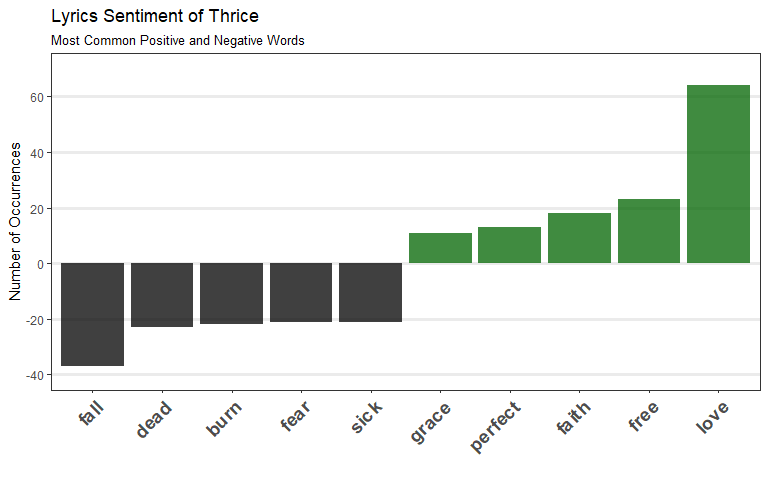

```r
word_count <- emotions_lyrics_bing %>%
  count(word, sentiment, sort = T) %>%
  ungroup()

top_sentiments_bing <-  word_count %>%
  filter(sentiment != 'neutral') %>%
  group_by(sentiment) %>%
  top_n(5, n) %>%
  mutate(num = ifelse(sentiment == "negative", -n, n)) %>%
  select(-n) %>%
  mutate(word = reorder(word, num)) %>%
  ungroup()

ggplot(top_sentiments_bing, aes(reorder(word, num), num, fill = sentiment)) +
  geom_bar(stat = 'identity', alpha = 0.75) +
  scale_fill_manual(guide = F, values = c("black", "darkgreen")) +
  scale_y_continuous(limits = c(-40, 70), breaks = pretty_breaks(7)) +
  labs(x = '', y = "Number of Occurrences",
       title = 'Lyrics Sentiment of Thrice',
       subtitle = 'Most Common Positive and Negative Words') +
  theme_bw() +
  theme(axis.text.x = element_text(angle = 45, hjust = 1, size = 14, face = "bold"),
        panel.grid.minor = element_blank(),
        panel.grid.major.x = element_blank(),
        panel.grid.major.y = element_line(size = 1.1))
```

Reminiscent of the most common words plot (without “stop words”) from **Part 2** except this time we’ve differentiated between words with positive sentiment and negative sentiment! Another way to visualize this is using a wordcloud!

# Word Cloud: Most Common Positive and Negative Words in Thrice Lyrics

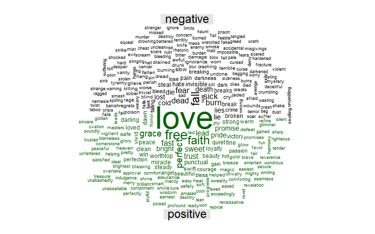

```r
library(wordcloud)   # to create wordcloud
library(reshape2)    # for acast() function

emotions_lyrics_bing %>%
  filter(sentiment != 'neutral') %>%
  count(word, sentiment, sort = T) %>%
  acast(word ~ sentiment, value.var = "n", fill = 0) %>%
  comparison.cloud(colors = c("black", "darkgreen"), title.size = 1.5)
```

With the size of the word dictated by the size and central position in the cloud, this is another cool way to visualize the most common words. As seen before for positive words, **Love** appears the most whereas for negative, **Fall** appears most frequently.

# Proportions of Positive and Negative Words

After filtering out the words categorized as neutral, we calculate the frequency by first grouping them along `sentiment` (the column specifying all the different emotion terms) and then counting the rows for each of these groups. Finally, we can calculate the percentage by dividing by the sum of all the rows in the dataset.

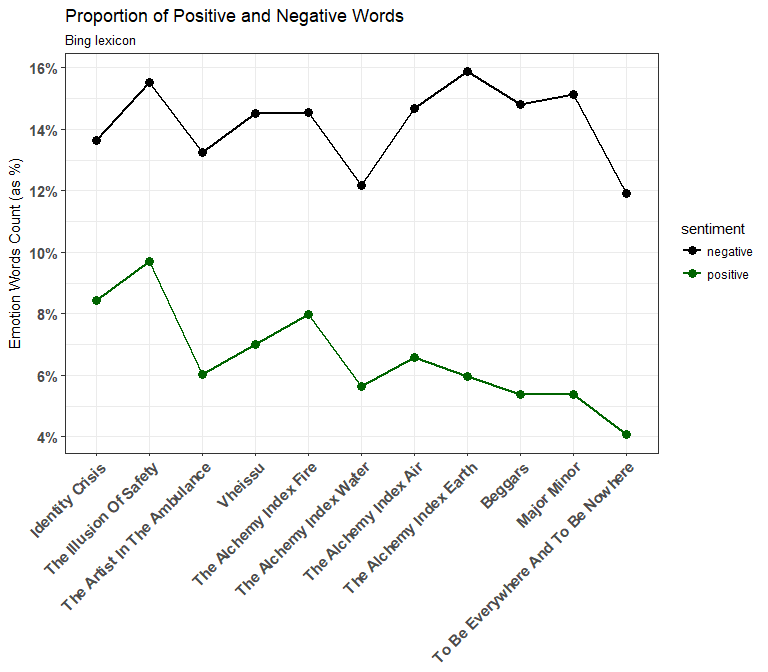

```r
pos_neg_bing <- tidy_lyrics %>%
  filter(!grepl('[0-9]', word)) %>%
  left_join(get_sentiments("bing"), by = "word") %>%
  mutate(sentiment = ifelse(is.na(sentiment), 'neutral', sentiment)) %>%
  group_by(album, sentiment) %>%
  summarize(n = n()) %>%
  mutate(percent = n / sum(n)) %>%
  select(-n) %>%
  ungroup()

pos_neg_bing %>%
  filter(sentiment != "neutral") %>%
  ggplot(aes(x = album, y = percent, color = sentiment, group = sentiment)) +
  geom_line(size = 1) +
  geom_point(size = 3) +
  scale_y_continuous(breaks = pretty_breaks(5), labels = percent_format()) +
  labs(x = "Album", y = "Emotion Words Count (as %)") +
  scale_color_manual(values = c(positive = "darkgreen", negative = "black")) +
  ggtitle("Proportion of Positive and Negative Words", subtitle = "Bing lexicon") +
  theme_bw() +
  theme(axis.text.x = element_text(angle = 45, hjust = 1, size = 11, face = "bold"),
        axis.title.x = element_blank(),
        axis.text.y = element_text(size = 11, face = "bold"))
```

As we saw when we counted the words categorized for each sentiment at the beginning of the article, the **neutral** sentiment (not shown above) dominates, so both the *positive* and *negative* percentages move around a very low range. However, just looking at positive and negative sentiment groups may not be informative enough, let’s use the **NRC** lexicon to dig deeper!

# Boxplot of emotion terms

The NRC lexicon not only categorizes words into *positive* and *negative* categories but also into eight different emotion terms, `Anger`, `Anticipation`, `Disgust`, `Fear`, `Joy`, `Sadness`, `Surprise`, and `Trust`.

After filtering out the words categorized as positive/negative as we are only comparing between the emotion terms here, and do the same calculations as we did for the previous plot.

Let’s use the colors from Set1 in the RColorBrewer palettes to differntiate our emotion terms in the plot. We’ll use these assigned colors for some line charts later on too!

```r
cols <- colorRampPalette(brewer.pal(n = 8, name = "Set1"))(8)

cols
```

```
## [1] "#E41A1C" "#377EB8" "#4DAF4A" "#984EA3" "#FF7F00" "#FFFF33" "#A65628"
## [8] "#F781BF"
```

**“#E41A1C”**, **“#377EB8”**, etc. are the color hex codes for the colors in **“Set1”**. Now that we’ve extracted these color codes, let’s assign them to the emotion categories and then specify those are the colors we want to use for our lines with `scale_color_manual()` function.

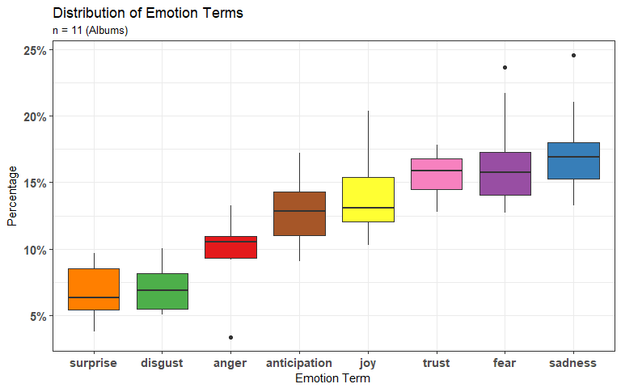

```r
cols <- c("anger" = "#E41A1C", "sadness" = "#377EB8", "disgust" = "#4DAF4A",
          "fear" = "#984EA3", "surprise" = "#FF7F00", "joy" = "#FFFF33",
          "anticipation" = "#A65628", "trust" = "#F781BF")

emotions_lyrics_nrc <- tidy_lyrics %>%
  left_join(get_sentiments("nrc"), by = "word") %>%
  filter(!(sentiment == "negative" | sentiment == "positive")) %>%
  mutate(sentiment = as.factor(sentiment)) %>%
  group_by(album, sentiment) %>%
  summarize(n = n()) %>%
  mutate(percent = n / sum(n)) %>%
  select(-n) %>%
  ungroup()

library(hrbrthemes)

emotions_lyrics_nrc %>%
  ggplot() +
  geom_boxplot(aes(x = reorder(sentiment, percent), y = percent, fill = sentiment)) +
  scale_y_continuous(breaks = pretty_breaks(5), labels = percent_format()) +
  scale_fill_manual(values = cols) +
  ggtitle("Distribution of Emotion Terms", subtitle = "n = 11 (Albums)") +
  labs(x = "Emotion Term", y = "Percentage") +
  theme_bw() +
  theme(legend.position = "none",
        axis.text.x = element_text(size = 11, face = "bold"),
        axis.text.y = element_text(size = 11, face = "bold"))
```

we can clearly see the box-plot distributions of the different emotion categories! As in any boxplot, the black bar inside the box signifies the median, the hinges represent the 25th and 75th percentiles, while the whiskers extend to the value of 1.5 * IQR of their respective hinges, and the black dots are the outliers. But suppose we want to see how the lyrics change sentiment over time? We can create a bump chart that plots the different sentiment groups for each album in order of release-date!

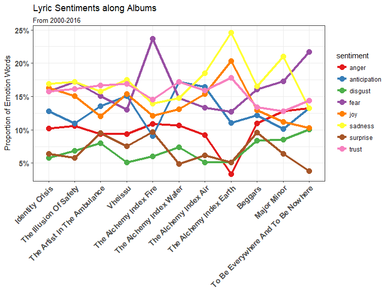

```r
emotions_lyrics_nrc %>%
  ggplot(aes(album, percent, color = sentiment, group = sentiment)) +
  geom_line(size = 1.5) +
  geom_point(size = 3.5) +
  scale_y_continuous(breaks = pretty_breaks(5), labels = percent_format()) +
  xlab("Album") + ylab("Proportion of Emotion Words") +
  ggtitle("Lyric Sentiments along Albums", subtitle = "From 2000-2016") +
  theme_bw() +
  theme(axis.text.x = element_text(angle = 45, hjust = 1, size = 11, face = "bold"),
        axis.title.x = element_blank(),
        axis.text.y = element_text(size = 11, face = "bold")) +
  scale_color_brewer(palette = "Set1")
```

With EIGHT different emotions (`Anger`, `Anticipation`, `Disgust`, `Fear`, `Joy`, `Sadness`, `Surprise`, and `Trust`) in the **NRC** lexicon our nice graph looks quite cluttered and its hard to spot the trends, although it is quite clear that **The Alchemy Index: Earth** is the source of a lot of sudden increases/decreases in emotions.

To solve our current problem, let’s split the emotions into groups to be able to see changes better! These emotion terms won’t perfectly group up but let’s divide them into:

- `Anger`, `Disgust`, `Fear`, and `Sadness`  
  and
- `Surprise`, `Anticipation`, `Joy`, and `Trust`

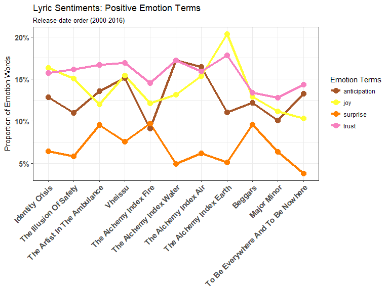

```r
emotions_lyrics_nrc %>%
  filter(sentiment != "anger" & sentiment != "disgust" &
         sentiment != "fear" & sentiment != "sadness") %>%
  ggplot(aes(album, percent, color = sentiment, group = sentiment)) +
  geom_line(size = 1.5) +
  geom_point(size = 3.5) +
  scale_y_continuous(breaks = pretty_breaks(5), labels = percent_format()) +
  xlab("Album") + ylab("Proportion of Emotion Words") +
  ggtitle("Lyric Sentiments: Positive Emotion Terms", subtitle = "Release-date order (2000-2016)") +
  theme_bw() +
  theme(axis.text.x = element_text(angle = 45, hjust = 1, size = 11, face = "bold"),
        axis.title.x = element_blank(),
        axis.text.y = element_text(size = 11, face = "bold")) +
  scale_color_manual(values = cols, name = "Emotion Terms")
```

`Anticipation` seems to have dramatic dips in **AI: Fire** and **AI: Earth** compared to the preceding albums. Meanwhile `Joy` reaches the highest point for positive emotions at ~20% in **AI: Earth** while `Trust` seems to hover around 15-17% throughout Thrice’s discography until the last few albums.

And next, the negative emotions.

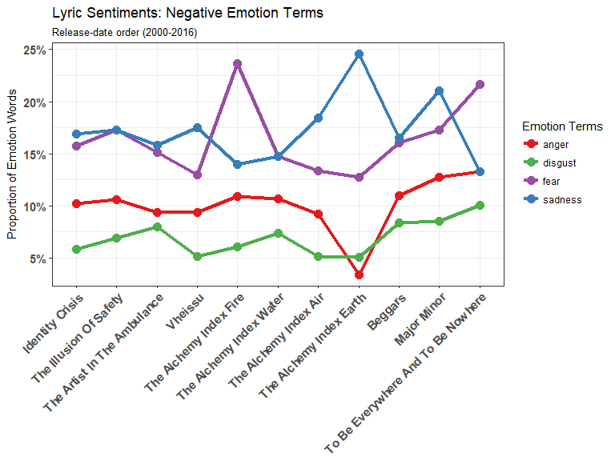

```r
emotions_lyrics_nrc %>%
  filter(sentiment != "anticipation" & sentiment != "joy" &
         sentiment != "trust" & sentiment != "surprise") %>%
  ggplot(aes(album, percent, color = sentiment, group = sentiment)) +
  geom_line(size = 1.5) +
  geom_point(size = 3.5) +
  scale_y_continuous(breaks = pretty_breaks(5), labels = percent_format()) +
  labs(x = "Album", y = "Proportion of Emotion Words") +
  ggtitle("Lyric Sentiments: Negative Emotion Terms", subtitle = "Release-date order (2000-2016)") +
  theme_bw() +
  theme(axis.text.x = element_text(angle = 45, hjust = 1, size = 11, face = "bold"),
        axis.title.x = element_blank(),
        axis.text.y = element_text(size = 11, face = "bold")) +
  scale_color_manual(values = cols, name = "Emotion Terms")
```

**AI: Earth** seems bereft in sentiments in general… besides joy and sadness while **AI: Fire** seems to have untrendly amount of `Fear`: let’s take a closer look!

```r
nrc_fear <- get_sentiments("nrc") %>%
  filter(sentiment == "fear")

tidy_lyrics %>%
  filter(album == "The Alchemy Index Fire") %>%
  inner_join(nrc_fear) %>%
  count(word, sort = TRUE) %>%
  head(5)
```

```
## # A tibble: 5 x 2
##      word     n
##     <chr> <int>
## 1    fire    10
## 2    fear     4
## 3  buried     2
## 4     die     2
## 5 gallows     2
```

In **AI: Fire**, the word “fire” being tagged as Fear is what is mainly pushing the proportion of `Fear` up so high. The other words categorized, such as “fear”, “buried”, “die”, and “gallows”, definitely belong in this category as well.

```r
nrc_anger <- get_sentiments("nrc") %>%
  filter(sentiment == "anger")

tidy_lyrics %>%
  filter(album == "The Alchemy Index Earth") %>%
  inner_join(nrc_anger) %>%
  count(word, sort = TRUE)
```

```
## # A tibble: 4 x 2
##      word     n
##     <chr> <int>
## 1   argue     1
## 2  cancer     1
## 3 mocking     1
## 4   rebel     1
```

```r
tidy_lyrics %>%
  filter(str_detect(album, "The Alchemy")) %>%
  inner_join(nrc_anger) %>%
  count(album, word, sort = TRUE) %>%
  group_by(album) %>%
  summarize(n = n())
```

```
## # A tibble: 4 x 2
##                     album     n
##                    <fctr> <int>
## 1  The Alchemy Index Fire    12
## 2 The Alchemy Index Water    12
## 3   The Alchemy Index Air    10
## 4 The Alchemy Index Earth     4
```

Words categorized as Anger only appear four times! In the other AI albums `Anger` words appear much more frequently (and the proportions would also drastically change as well)! A separate article looking at only the AI albums may be interesting.

# Net sentiment ratio for each song

Similar to what we did when we looked at the proportion of *positive*, *negative*, and *neutral* words in our data, we can calculate a **net sentiment ratio** for each song.

```r
emotions_lyrics_bing %>%
  group_by(title) %>%
  count(sentiment) %>%
  spread(key = sentiment, value = n, fill = 0) %>%
  # replace_na(replace = list(negative = 0, neutral = 0, positive = 0)) %>%
  mutate(sentiment_ratio = (positive - negative) / (positive + negative + neutral)) %>%
  "["(., 5:9, )
```

```
## # A tibble: 5 x 5
## # Groups:   title [5]
##                  title negative neutral positive sentiment_ratio
##                  <chr>    <dbl>   <dbl>    <dbl>           <dbl>
## 1      All That's Left       22      53        6     -0.19753086
## 2 All The World Is Mad       38      50        6     -0.34042553
## 3            Anthology        1      37        9      0.17021277
## 4    As The Crow Flies        2      28        0     -0.06666667
## 5    As The Ruin Falls        6       8        2     -0.25000000
```

We can fill out any NAs in the sentiment columns into zeros by either using the `replace_na()` from the `tidyr` package OR in `spread()` use the argument `fill = 0`!

Now let’s create a new dataset that takes these sentiment ratios, group them by album, and then take the average for each album.

```r
emotions_lyrics_bing_avg <- emotions_lyrics_bing %>%
  group_by(title, album) %>%
  count(sentiment) %>%
  spread(key = sentiment, value = n, fill = 0) %>%
  mutate(sentiment_ratio = (positive - negative) / (positive + negative + neutral)) %>%
  ungroup() %>%
  group_by(album) %>%
  summarize(mean_album_ratio = mean(sentiment_ratio))

emotions_lyrics_bing_avg
```

```
## # A tibble: 11 x 2
##                                 album mean_album_ratio
##                                <fctr>            <dbl>
##  1                    Identity Crisis      -0.06856545
##  2             The Illusion Of Safety      -0.05835762
##  3        The Artist In The Ambulance      -0.06872474
##  4                            Vheissu      -0.08303573
##  5             The Alchemy Index Fire      -0.06718283
##  6            The Alchemy Index Water      -0.05468557
##  7              The Alchemy Index Air      -0.07321387
##  8            The Alchemy Index Earth      -0.09113008
##  9                            Beggars      -0.09720519
## 10                        Major Minor      -0.08062639
## 11 To Be Everywhere And To Be Nowhere      -0.07793662
```

Let’s visualize this info!

# Sentiment ratio graph

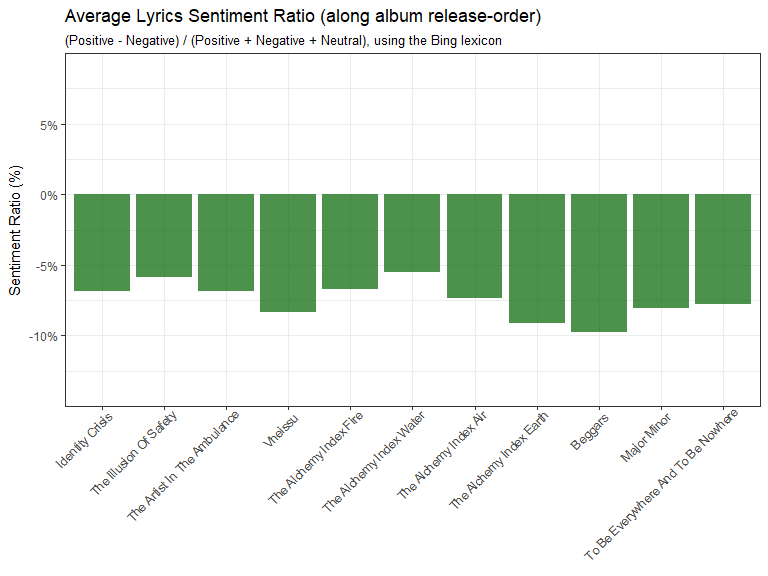

```r
emotions_lyrics_bing_avg %>%
  ggplot(aes(album, mean_album_ratio)) +      # reorder(album, sentiment_ratio), sentiment_ratio
  geom_col(fill = "darkgreen", alpha = 0.7) +
  scale_fill_manual(guide = FALSE, values = c('#565b63', '#c40909')) +
  scale_y_percent(limits = c(-0.15, 0.10), breaks = pretty_breaks(7)) +    # from hrbrthemes
  theme_bw() +
  theme(axis.title.x = element_blank(),
        axis.text.x = element_text(angle = 45, hjust = 0.95)) +
  ggtitle("Average Lyrics Sentiment Ratio (along album release-order)",
          subtitle = "(Positive - Negative) / (Positive + Negative + Neutral), using the Bing lexicon") +
  labs(x = "Albums", y = "Sentiment Ratio (%)")
```

We’ve seen in previous plots that the sentiment of albums were more *negative* than *positive* and this plot confirms this as well. Why are Thrice’s lyrics categorized as negative as they are? From my experience a lot of Thrice’s songs are about acknowledging struggles/sins/negatives and overcoming them. Let’s look at how negative is defined by the three different lexicons.

Let’s compare the lexicons themselves on how many *positive* and *negative* words they each categorize.

```r
get_sentiments("bing") %>%
  count(sentiment)
```

```
## # A tibble: 2 x 2
##   sentiment     n
##       <chr> <int>
## 1  negative  4782
## 2  positive  2006
```

```r
get_sentiments("nrc") %>%
  count(sentiment)
```

```
## # A tibble: 10 x 2
##       sentiment     n
##           <chr> <int>
##  1        anger  1247
##  2 anticipation   839
##  3      disgust  1058
##  4         fear  1476
##  5          joy   689
##  6     negative  3324
##  7     positive  2312
##  8      sadness  1191
##  9     surprise   534
## 10        trust  1231
```

- In the **Bing** lexicon: there are 4782 words that can be categorized as *negative* along with 2006 *positive* words.
- In the **NRC** lexicon: there are 3324 words that can be categorized as *negative* along with 2312 *positive* words.

In the **Bing** lexicon, there are far more *negative*-categorized words than *positive*… more than twice as many in fact!

Now let’s count how many words in the lyrics were categorized for each sentiment:

```r
emotions_lyrics_bing %>%
  group_by(sentiment) %>%
  summarize(sum = n())
```

```
## # A tibble: 3 x 2
##   sentiment   sum
##       <chr> <int>
## 1  negative   912
## 2   neutral  5095
## 3  positive   423
```

```r
tidy_lyrics %>%
  left_join(get_sentiments("nrc"), by = "word") %>%
  group_by(sentiment) %>%
  summarize(sum = n())
```

```
## # A tibble: 11 x 2
##       sentiment   sum
##           <chr> <int>
##  1        anger   353
##  2 anticipation   425
##  3      disgust   244
##  4         fear   555
##  5          joy   455
##  6     negative   917
##  7     positive   846
##  8      sadness   570
##  9     surprise   235
## 10        trust   514
## 11         <NA>  4392
```

- In the lyrics (**Bing**): there are 912 *negative* words along with 423 *positive* words.
- In the lyrics (**NRC**): there are 917 *negative* words along with 846 *positive* words.

Both the **NRC** and **Bing** lexicons didn’t have a category for most of the words in Thrice lyrics (*neutral* or *NA*) and there were more negative words than positive.

Let’s see if this holds true with the **AFINN** lexicon, the only lexicon we haven’t touched yet in the `tidytext` package! The AFINN lexicon gives a score from -5 (for *negative* sentiment) to +5 (*positive* sentiment).

```r
emotions_lyrics_afinn <- tidy_lyrics %>%
  left_join(get_sentiments("afinn"), by = "word") %>%
  filter(!grepl('[0-9]', word))

emotions_lyrics_afinn %>%
  summarize(NAs= sum(is.na(score)))
```

```
##    NAs
## 1 5220
```

```r
emotions_lyrics_afinn %>%
  select(score) %>%
  mutate(sentiment = if_else(score > 0, "positive", "negative", "NA")) %>%
  group_by(sentiment) %>%
  summarize(sum = n())
```

```
## # A tibble: 3 x 2
##   sentiment   sum
##       <chr> <int>
## 1        NA  5220
## 2  negative   696
## 3  positive   514
```

5220 of 6430 words in our lyrics dataset dont have **AFINN** score… With so many words in Thrice’s lyrics not categorized by any of these lexicons our results won’t be the most comprehensive, but these will have to do for now!

In line with the other lexicons, the majority of the words were categorized into NA (*neutral*)… then words were categorized as *negative* at a higher frequency compared to *positive*.

To create another visualization of lyrics sentiment, instead of taking the average for each album, we’ll just take the sentiment score for each album and plot it along each song. This way we’ll have more observations to compare the sentiment scoring ability of each lexicon.

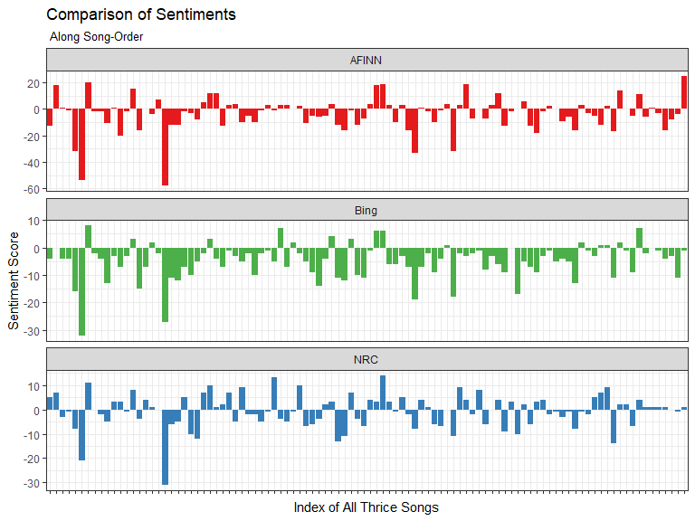

```r
afinn_scores <- emotions_lyrics_afinn %>%
  replace_na(replace = list(score = 0)) %>%
  group_by(index = title) %>%
  summarize(sentiment = sum(score)) %>%
  mutate(lexicon = "AFINN")

# combine the Bing and NRC lexicons into one data frame:

bing_nrc_scores <- bind_rows(
  tidy_lyrics %>%
    inner_join(get_sentiments("bing")) %>%
    mutate(lexicon = "Bing"),
  tidy_lyrics %>%
    inner_join(get_sentiments("nrc") %>%
                 filter(sentiment %in% c("positive", "negative"))) %>%
    mutate(lexicon = "NRC")) %>%
  # from here we count the sentiments, spread on positive/negative, then create the score:
  count(lexicon, index = title, sentiment) %>%
  spread(sentiment, n, fill = 0) %>%
  mutate(lexicon = as.factor(lexicon),
         sentiment = positive - negative)

all_lexicons <- bind_rows(afinn_scores, bing_nrc_scores)
lexicon_cols <- c("AFINN" = "#E41A1C", "NRC" = "#377EB8", "Bing" = "#4DAF4A")

all_lexicons %>%
  ggplot(aes(index, sentiment, fill = lexicon)) +
  geom_col(show.legend = FALSE) +
  facet_wrap(~lexicon, ncol = 1, scales = "free_y") +
  scale_fill_manual(values = lexicon_cols) +
  ggtitle("Comparison of Sentiments", subtitle = " Along Song-Order") +
  labs(x = "Index of All Thrice Songs", y = "Sentiment Score") +
  theme_bw() +
  theme(axis.text.x = element_blank())
```

There are too many songs (103!) to show on the x-axis labels but I think you get the general idea!

The **Bing** lexicon sentiment along song order is generally *negative*, this lines up with what we saw in the average sentiment ratio plot where we had plotted along album order instead.

As we go through the songs from the first track on **Identity Crisis**, the eponymous *“Identity Crisis”*, all the way down to the last track on last year’s **To Be Everywhere Is To Be Nowhere**, *“Salt And Shadow”*, the **AFINN**, **Bing**, and **NRC** lexicons seem to agree on the sentiments but differ in the magnitude of the expressed sentiment for a each song.

The **AFINN** lexicon has the largest absolute magnitudes, however, remember that only 1210 out of 6430 total words in the lyrics were given a **AFINN** score. This means that the few words that do have scores exaggerate the magnitude of the sentiment scores relative to the other lexicons.

Keep in mind that the lexicons in the `tidytext` package are not the be all and end all for text/sentiment analysis. One can even create their own lexicons through crowd-sourcing (such as Amazon MechanicalTurk, which is how some of the lexicons shown here were created), from utilizing word lists accrued by your own company throughout the years dealing with customer/employee feedback, etc. The sources are limitless!

In the next article we’ll look at separating our lyrics into **bi-grams** (two words-per-row; which can then be split up into `word1` and `word2`) and examining how the presence of *negation* words (“not”, “never”, “can’t”, “won’t”, etc.) is causing the lexicons to misclassify sentiments of the lyrics!

## Preview for Part 4

Here’s a little preview of what examining negation words in bi-grams looks like. In the plot below we created a new variable called `contribution` where we multiplied the **AFINN** score of `word2` (the word coming after a *negation* word `word1`) with their frequency to see the full effect of each negation bi-gram on the overall sentiment.

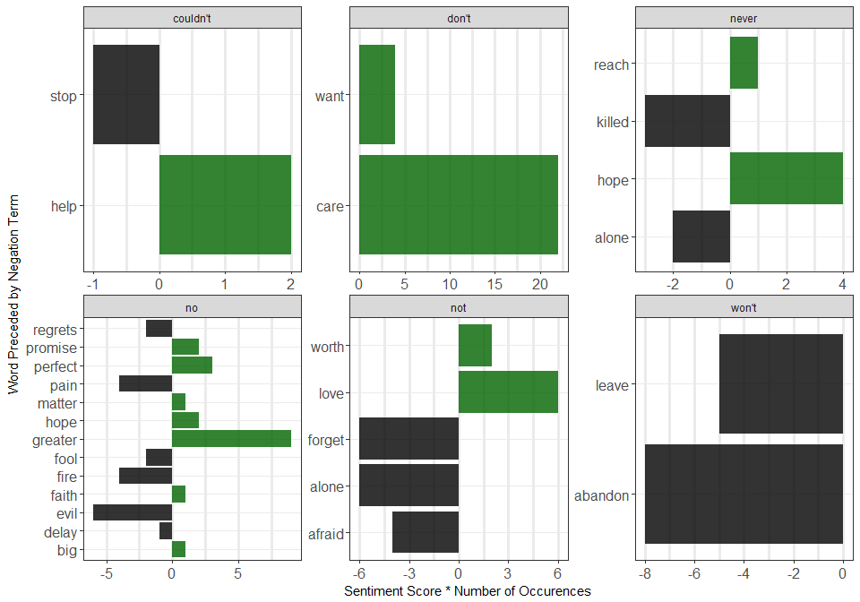